# US Census Demographic Data

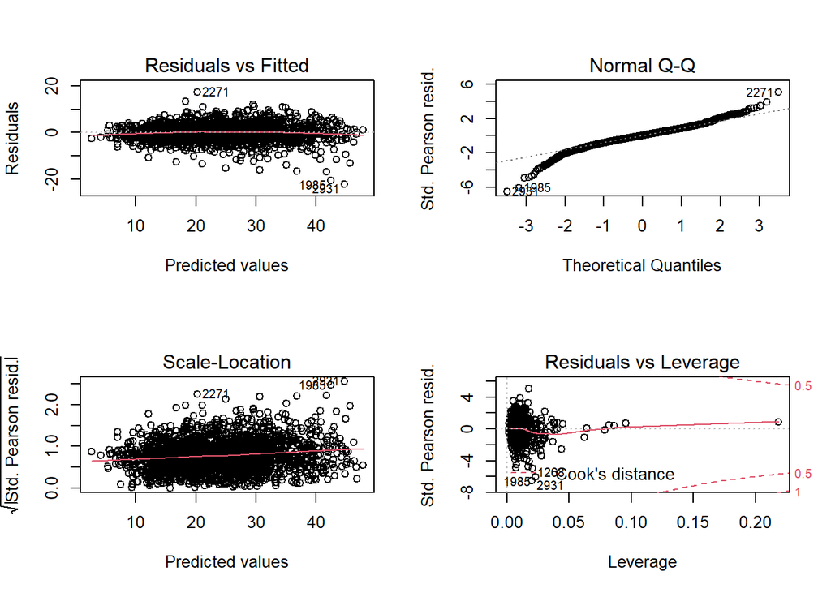

```r
pred_p<-predict(lm_p,data.frame(Unemployment=Adata9$Unemployment))
mse_p<-mean((pred_p-Adata9$ChildPoverty)^2)
mse_p

subset1<-subset(Adata9,select = -c(CensusId,State,County))
lm1<-glm(ChildPoverty~.,data=subset1)
summary(lm1)
par(mfrow=c(2,2))
plot(lm1)

subset1<-subset(subset1,select = -Women)
lm2<-glm(ChildPoverty~.,data=subset1)
summary(lm2)
par(mfrow=c(2,2))
plot(lm2)
```

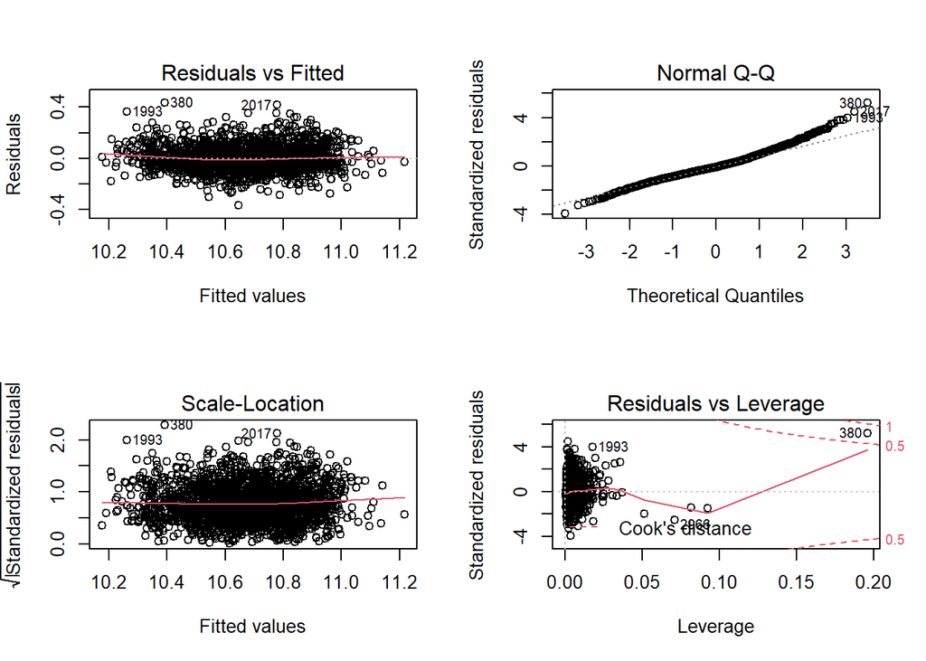

```r
library(FNN)
set.seed(1) ## the seed can be arbitrary but we use 1 for the sake of consistency
fold.index <- cut(sample(1:nrow(subset1)),breaks=10,labels=FALSE)
mse_l<-rep(0,10)
error_l<-rep()
for (i in 1:10) {
  fit_l<-glm(log(Income)~.,data=subset1[fold.index!=i,])
  result_l<-exp(predict(fit_l,subset1[fold.index==i,]))
  mse_l[i]<-mean((result_l-subset1[fold.index==i,5])^2)
}
mse_l<-mean(mse_l)
mse_l
lm3<-lm(log(Income)~TotalPop+Men+Citizen+Poverty+ChildPoverty+WorkAtHome+Employed+Unemployment,data=subset1)
summary(lm3)
plot(lm3)
```

As long as all the above variables are checked for normal distribution in Chapter 3, you can run tests directly on them. The independent and dependent variables “child poverty” are all quantitative, so ttest is the best choice for testing hypotheses.

```
##
##  Welch Two Sample t-test
##
## data:  iu_sample$ChildPoverty and il_sample$ChildPoverty
## t = -10, df = 94, p-value = 7e-16
## alternative hypothesis: true difference in means is not equal to 0
## 95 percent confidence interval:
##  -15.8 -10.5
## sample estimates:
## mean of x mean of y
##      16.8      30.0
```

```
##
##  Welch Two Sample t-test
##
## data:  pov_sample$ChildPoverty and pov_sample$ChildPoverty
## t = 0, df = 98, p-value = 1
## alternative hypothesis: true difference in means is not equal to 0
## 95 percent confidence interval:
##  -1.86  1.86
## sample estimates:
## mean of x mean of y
##      18.2      18.2
```

```
##
##  Welch Two Sample t-test
##
## data:  pu_sample$ChildPoverty and pl_sample$ChildPoverty
## t = -4, df = 97, p-value = 9e-05
## alternative hypothesis: true difference in means is not equal to 0
## 95 percent confidence interval:
##  -9.47 -3.27
## sample estimates:
## mean of x mean of y
##      20.8      27.2
```

```
##
##  Welch Two Sample t-test
##
## data:  su_sample$ChildPoverty and sl_sample$ChildPoverty
## t = 3, df = 97, p-value = 0.005
## alternative hypothesis: true difference in means is not equal to 0
## 95 percent confidence interval:
##  1.55 8.63
## sample estimates:
## mean of x mean of y
##      27.5      22.4
```

```
##
##  Welch Two Sample t-test
##
## data:  produ_sample$ChildPoverty and prodl_sample$ChildPoverty
## t = 2, df = 98, p-value = 0.04
## alternative hypothesis: true difference in means is not equal to 0
## 95 percent confidence interval:
##  0.216 7.712
## sample estimates:
## mean of x mean of y
##      25.3      21.3
```

```
##
##  Welch Two Sample t-test
##
## data:  wu_sample$ChildPoverty and wl_sample$ChildPoverty
## t = -5, df = 97, p-value = 1e-05
## alternative hypothesis: true difference in means is not equal to 0
## 95 percent confidence interval:
##  -9.96 -4.02
## sample estimates:
## mean of x mean of y
##      19.3      26.3
```

P-value for “WorkAtHome’ is extremely small, we have sufficient evidence to state that”WorkAtHome’ is an effecting factor for ‘ChildPoverty’.

```
##
##  Welch Two Sample t-test
##
## data:  pubu_sample$ChildPoverty and publ_sample$ChildPoverty
## t = 1, df = 93, p-value = 0.3
## alternative hypothesis: true difference in means is not equal to 0
## 95 percent confidence interval:
##  -1.60  5.31
## sample estimates:
## mean of x mean of y
##      24.3      22.4
```

P-value for ‘PublicWork’ is greater than 0.05, so it is not an effecting factor for ‘Poverty’.

```
##
##  Welch Two Sample t-test
##
## data:  semu_sample$ChildPoverty and seml_sample$ChildPoverty
## t = -2, df = 92, p-value = 0.1
## alternative hypothesis: true difference in means is not equal to 0
## 95 percent confidence interval:
##  -6.748  0.756
## sample estimates:
## mean of x mean of y
##      22.9      25.9
```

P-value for ‘SelfEmployment’ is 0.1 which is greater than 0.05, we can not reject $H_0$, so it is not an effecting factor for ‘ChildPoverty’.

```
##
##  Welch Two Sample t-test
##
## data:  uemu_sample$ChildPoverty and ueml_sample$ChildPoverty
## t = 5, df = 97, p-value = 5e-06
## alternative hypothesis: true difference in means is not equal to 0
## 95 percent confidence interval:
##   4.61 10.98
## sample estimates:
## mean of x mean of y
##      28.5      20.7
```

Noticing that ‘State’ is left out from our correlation matrix since it is a categorical variable, we want to perform an ANOVA test to see if there’s difference in ‘ChildPoverty’ across different states.

```
##               Df Sum Sq Mean Sq F value Pr(>F)
## State         48  63108    1315    25.4 <2e-16 ***
## Residuals   2024 104682      52
## ---
## Signif. codes:  0 '***' 0.001 '**' 0.01 '*' 0.05 '.' 0.1 ' ' 1
```

As we can see in the results of ANOVA test, our p-value is extremely small, so we have sufficient evidence to reject the null and conclude that there is difference in ‘ChildPoverty’ for different states. In this case, ‘State’ is an effecting factor for ‘Poverty’. Finally, we will perform a Post-hoc test to see the pairs of states that have different ‘ChildPoverty’ as below. We will not display the result here since we not need this information to answer our SMART question, just save it for further analysis if needed.

when you understand how each independent variable’s mean is different from the others, you can begin to understand which of them has a connection to your dependent variable (such as landing page clicks) and begin to learn what is driving that behavior.

You could also flip things around and see whether or not a single independent variable (such as temperature) affects multiple dependent variables (such as purchase rates of suncream, attendance at outdoor venues, and likelihood to hold a cook-out) and if so, which ones.

### Chapter 6: Professional and Income Test.

First, we plotted histograms for both Professional and Income to see their distributions. Since the two histograms are approximately bell shaped (normally distributed), we can use them directly for modeling.

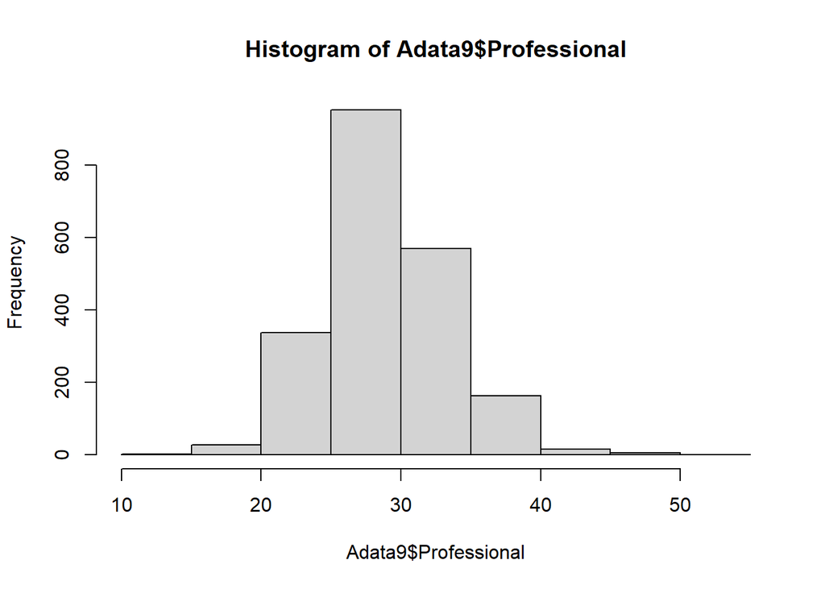

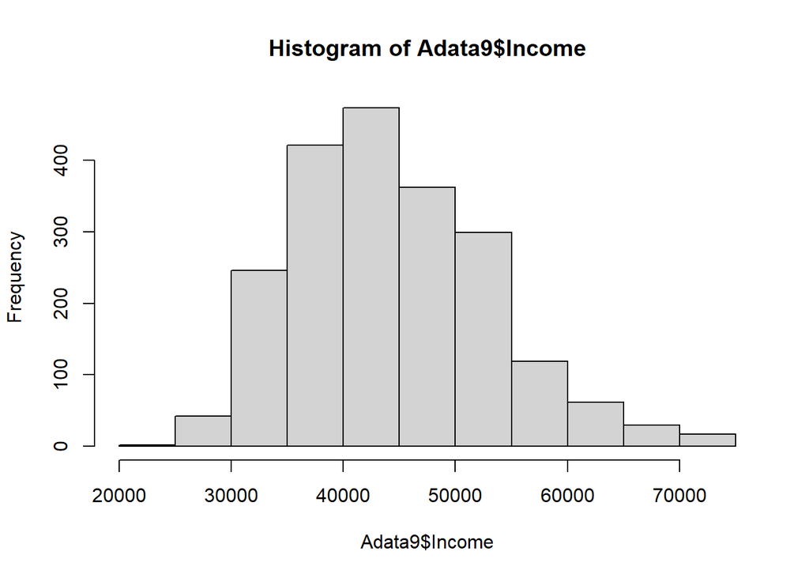

We will also plot a scatter plot to see the relationship between Professional and Income. The plot appears to have a pretty obvious linear pattern where Income increases as Professional increases. So we would like to fit a linear model to predict Income with Professional.

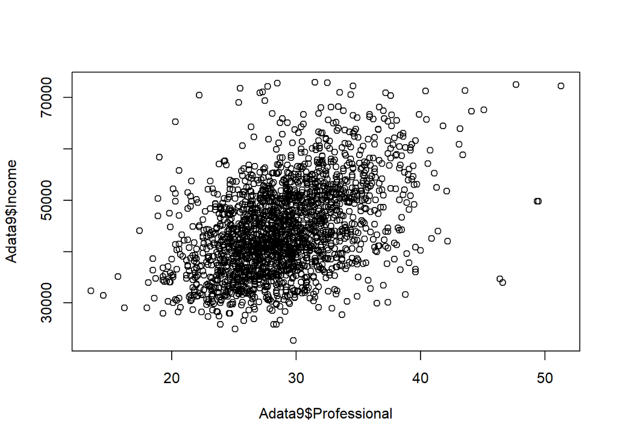

From the statistic summary of our model, we can see that in this single predictor model, Professional turns out to be a really significant factor impacting Income. For each 1 percent increase in population with professional jobs in each state, the average state income increases by 884.4.

Interpretations on the plots for our model:

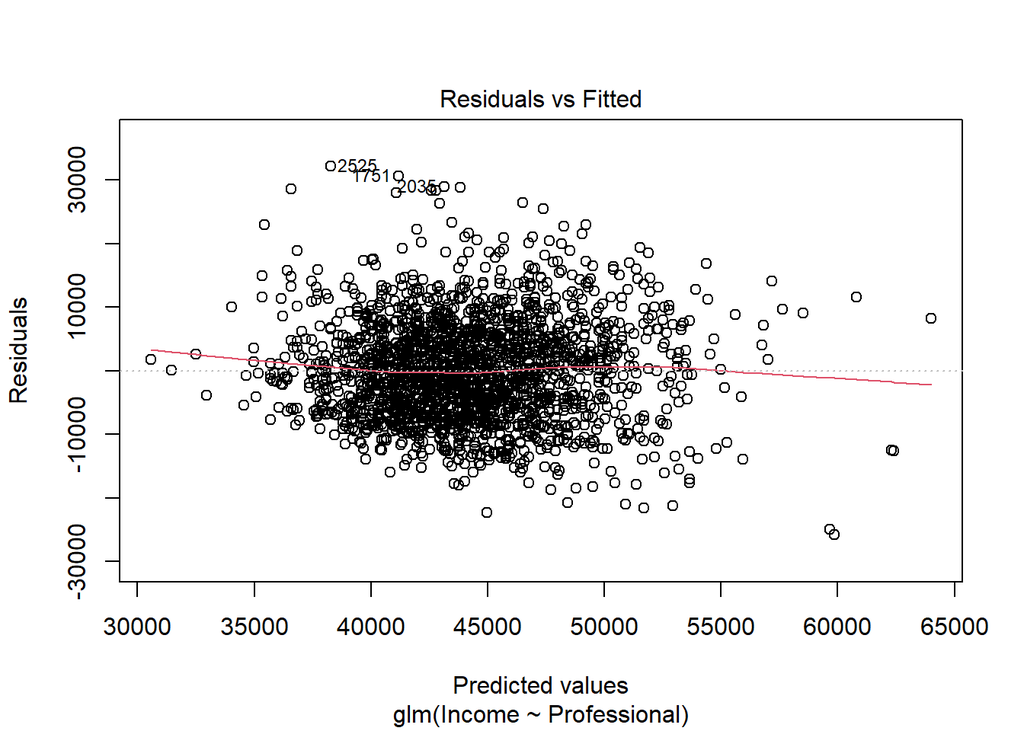

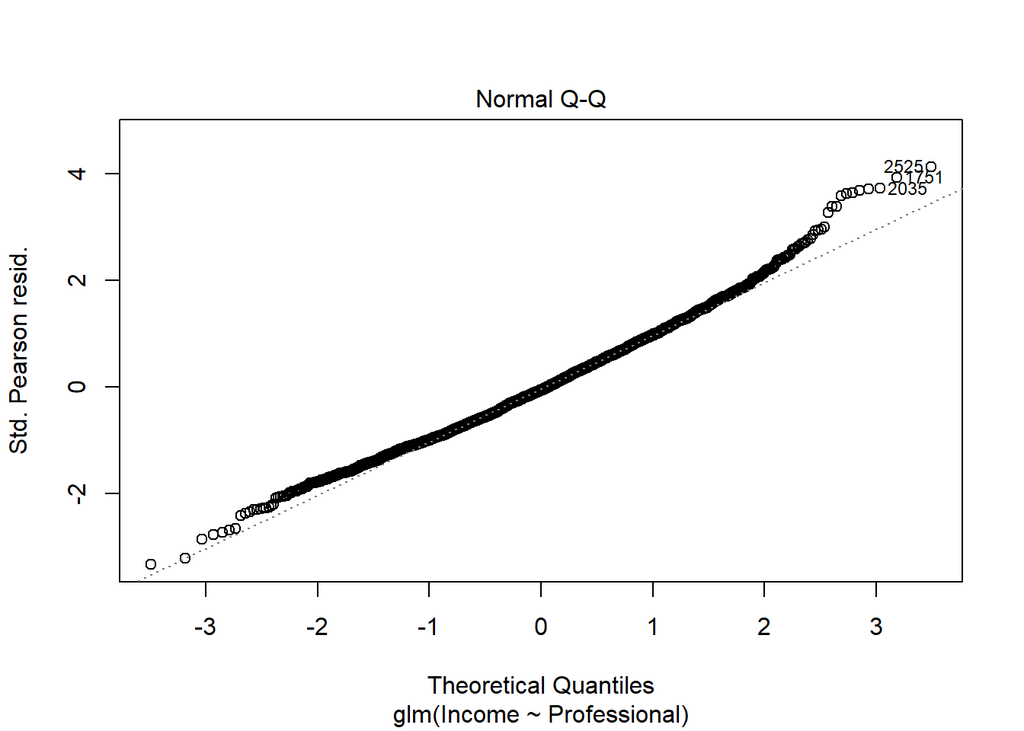

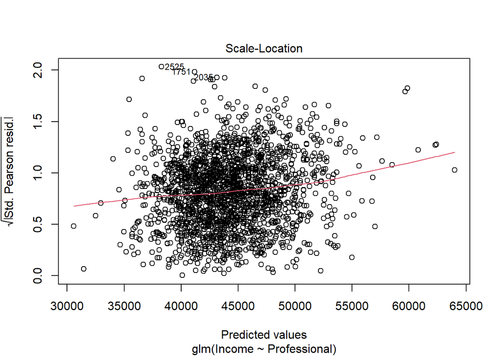

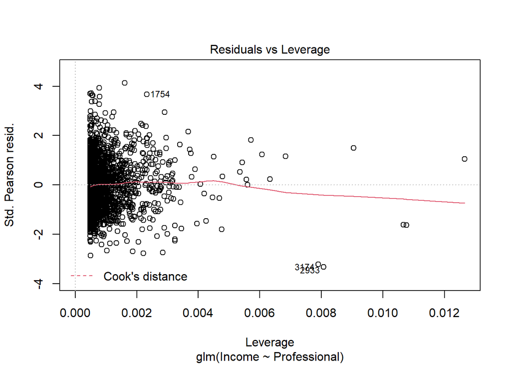

```
##
## Call:
## glm(formula = Income ~ Professional, data = Adata9)
##
## Deviance Residuals:
##    Min      1Q  Median      3Q     Max
## -25824   -5518    -464    4949   32160
##
## Coefficients:
##              Estimate Std. Error t value Pr(>|t|)
## (Intercept)   18629.7     1129.2    16.5   <2e-16 ***
## Professional    884.4       38.5    23.0   <2e-16 ***
## ---
## Signif. codes:  0 '***' 0.001 '**' 0.01 '*' 0.05 '.' 0.1 ' ' 1
##
## (Dispersion parameter for gaussian family taken to be 60746316)
##
##     Null deviance: 1.5782e+11  on 2072  degrees of freedom
## Residual deviance: 1.2581e+11  on 2071  degrees of freedom
## AIC: 43040
##
## Number of Fisher Scoring iterations: 2
##
## [1] 60687709
```

As we can see from the prediction, the mean squared error is pretty large. So can we fit a better model to predict Income with all the variables? What model and factors we should use to minimize the prediction error? Let’s use cross-validation to estimate the error for each model.

```
## [1] 60687709
```

*Linear Regression*

Fitting model with all predictors:

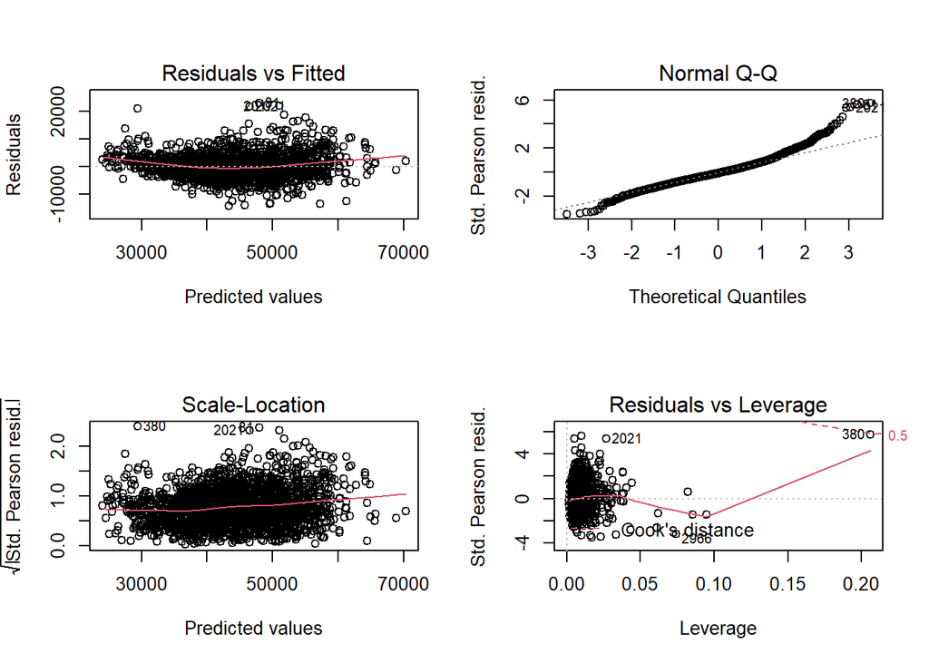

```
##
## Call:
## glm(formula = Income ~ ., data = subset1)
##
## Deviance Residuals:
##    Min      1Q  Median      3Q     Max
## -14213   -2476    -346    2091   22911
##
## Coefficients: (1 not defined because of singularities)
##               Estimate Std. Error t value Pr(>|t|)
## (Intercept)   1.07e+05   2.18e+05    0.49  0.62370
## TotalPop     -4.03e-01   1.08e-01   -3.73  0.00019 ***
## Men           1.29e+00   1.78e-01    7.21  7.9e-13 ***
## Women               NA         NA      NA       NA
## Citizen      -6.92e-01   6.02e-02  -11.49  < 2e-16 ***
## Poverty      -1.17e+03   4.34e+01  -26.95  < 2e-16 ***
## ChildPoverty  1.07e+02   2.61e+01    4.10  4.2e-05 ***
## Professional  3.02e+02   1.43e+03    0.21  0.83247
## Service      -1.66e+02   1.43e+03   -0.12  0.90770
## Office        9.22e+01   1.43e+03    0.06  0.94860
## Construction  1.41e+02   1.43e+03    0.10  0.92141
## Production   -1.28e+02   1.43e+03   -0.09  0.92851
## WorkAtHome    2.21e+02   6.46e+01    3.43  0.00063 ***
## Employed      7.65e-01   6.79e-02   11.27  < 2e-16 ***
## PrivateWork  -5.03e+02   1.61e+03   -0.31  0.75516
## PublicWork   -5.37e+02   1.61e+03   -0.33  0.73902
## SelfEmployed -9.21e+02   1.61e+03   -0.57  0.56757
## FamilyWork   -1.16e+03   1.62e+03   -0.72  0.47422
## Unemployment -6.67e+01   4.28e+01   -1.56  0.11956
## ---
## Signif. codes:  0 '***' 0.001 '**' 0.01 '*' 0.05 '.' 0.1 ' ' 1
##
## (Dispersion parameter for gaussian family taken to be 16772003)
##
##     Null deviance: 1.5782e+11  on 2072  degrees of freedom
## Residual deviance: 3.4466e+10  on 2055  degrees of freedom
## AIC: 40388
##
## Number of Fisher Scoring iterations: 2
```

As we can see form the summary, statistics for the variable “Women” are NAs, meaning that Women is probably a linear dependent pair with “Men”. So let’s drop this predictor.

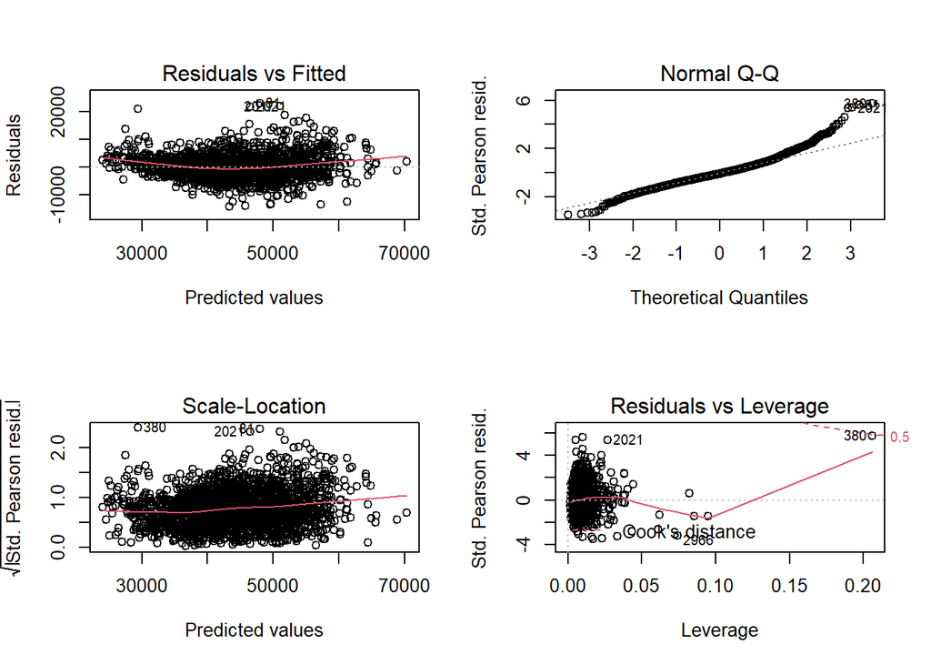

```
##
## Call:
## glm(formula = Income ~ ., data = subset1)
##
## Deviance Residuals:
##    Min      1Q  Median      3Q     Max
## -14213   -2476    -346    2091   22911
##
## Coefficients:
##               Estimate Std. Error t value Pr(>|t|)
## (Intercept)   1.07e+05   2.18e+05    0.49  0.62370
## TotalPop     -4.03e-01   1.08e-01   -3.73  0.00019 ***
## Men           1.29e+00   1.78e-01    7.21  7.9e-13 ***
## Citizen      -6.92e-01   6.02e-02  -11.49  < 2e-16 ***
## Poverty      -1.17e+03   4.34e+01  -26.95  < 2e-16 ***
## ChildPoverty  1.07e+02   2.61e+01    4.10  4.2e-05 ***
## Professional  3.02e+02   1.43e+03    0.21  0.83247
## Service      -1.66e+02   1.43e+03   -0.12  0.90770
## Office        9.22e+01   1.43e+03    0.06  0.94860
## Construction  1.41e+02   1.43e+03    0.10  0.92141
## Production   -1.28e+02   1.43e+03   -0.09  0.92851
## WorkAtHome    2.21e+02   6.46e+01    3.43  0.00063 ***
## Employed      7.65e-01   6.79e-02   11.27  < 2e-16 ***
## PrivateWork  -5.03e+02   1.61e+03   -0.31  0.75516
## PublicWork   -5.37e+02   1.61e+03   -0.33  0.73902
## SelfEmployed -9.21e+02   1.61e+03   -0.57  0.56757
## FamilyWork   -1.16e+03   1.62e+03   -0.72  0.47422
## Unemployment -6.67e+01   4.28e+01   -1.56  0.11956
## ---
## Signif. codes:  0 '***' 0.001 '**' 0.01 '*' 0.05 '.' 0.1 ' ' 1
##
## (Dispersion parameter for gaussian family taken to be 16772003)
##
##     Null deviance: 1.5782e+11  on 2072  degrees of freedom
## Residual deviance: 3.4466e+10  on 2055  degrees of freedom
## AIC: 40388
##
## Number of Fisher Scoring iterations: 2
```

According to the Residual vs Fitted plot, the fitted line is curved, so we are going to try some transformation on y to see if it will fix the non-linearity.

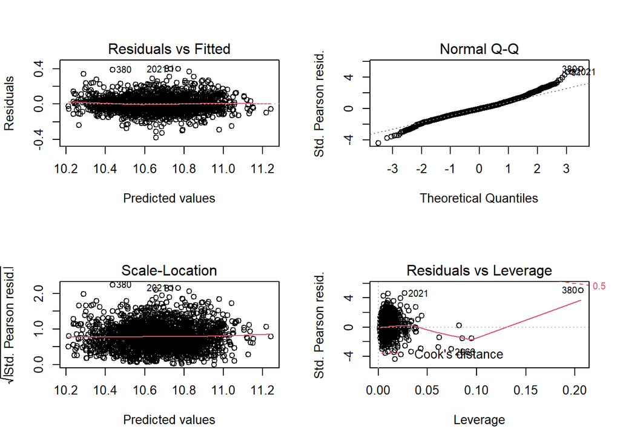

```
##
## Call:
## glm(formula = log(Income) ~ ., data = subset1)
##
## Deviance Residuals:
##     Min       1Q   Median       3Q      Max
## -0.3791  -0.0534  -0.0044   0.0471   0.3989
##
## Coefficients:
##               Estimate Std. Error t value Pr(>|t|)
## (Intercept)   9.63e+00   4.61e+00    2.09  0.03695 *
## TotalPop     -8.01e-06   2.29e-06   -3.50  0.00048 ***
## Men           2.71e-05   3.78e-06    7.17  1.1e-12 ***
## Citizen      -1.43e-05   1.28e-06  -11.15  < 2e-16 ***
## Poverty      -2.72e-02   9.20e-04  -29.53  < 2e-16 ***
## ChildPoverty  2.48e-03   5.54e-04    4.48  7.8e-06 ***
## Professional  1.76e-02   3.03e-02    0.58  0.56092
## Service       8.68e-03   3.03e-02    0.29  0.77468
## Office        1.37e-02   3.03e-02    0.45  0.65045
## Construction  1.48e-02   3.03e-02    0.49  0.62561
## Production    9.34e-03   3.03e-02    0.31  0.75799
## WorkAtHome    5.40e-03   1.37e-03    3.94  8.4e-05 ***
## Employed      1.50e-05   1.44e-06   10.42  < 2e-16 ***
## PrivateWork   1.62e-03   3.42e-02    0.05  0.96213
## PublicWork    9.03e-04   3.42e-02    0.03  0.97893
## SelfEmployed -6.70e-03   3.42e-02   -0.20  0.84446
## FamilyWork   -1.11e-02   3.44e-02   -0.32  0.74733
## Unemployment -2.94e-03   9.09e-04   -3.23  0.00125 **
## ---
## Signif. codes:  0 '***' 0.001 '**' 0.01 '*' 0.05 '.' 0.1 ' ' 1
##
## (Dispersion parameter for gaussian family taken to be 0.00754)
##
##     Null deviance: 79.017  on 2072  degrees of freedom
## Residual deviance: 15.501  on 2055  degrees of freedom
## AIC: -4228
##
## Number of Fisher Scoring iterations: 2
```

*CV error estimating for Linear model with all predictors*

```
## [1] 2e+09
```

Based on the summary for our previous linear model, what if we use only the significant predictors with a p-value < 0.05 to model Income?

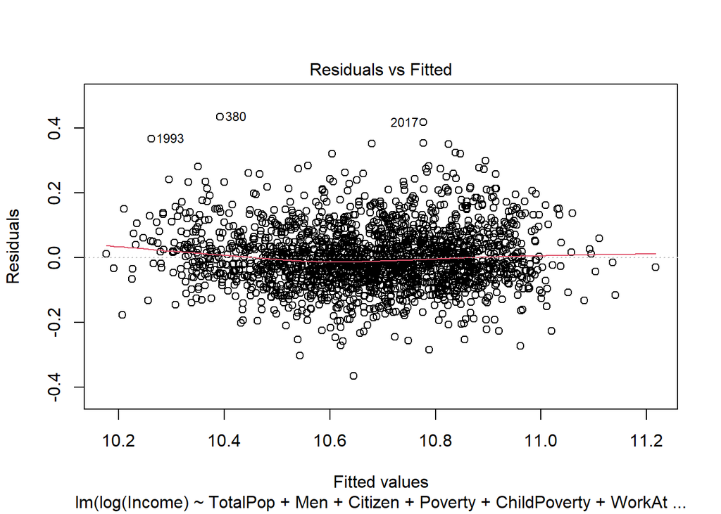

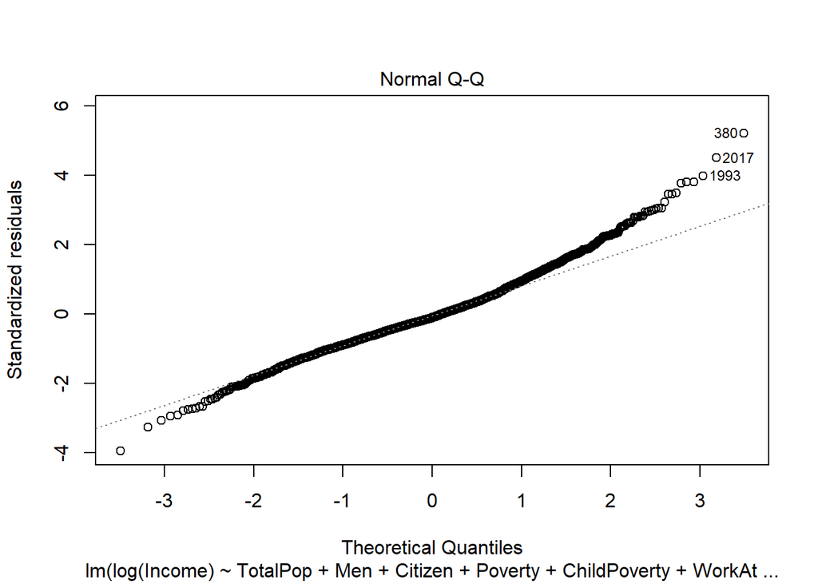

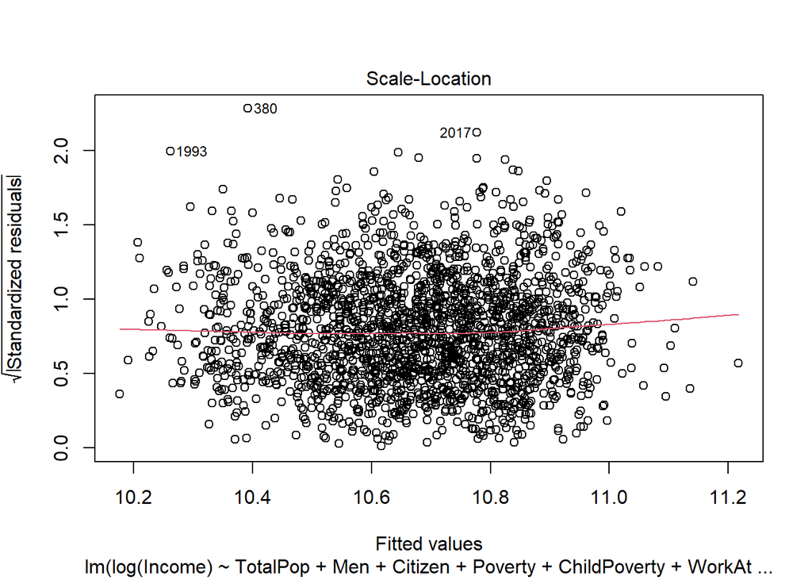

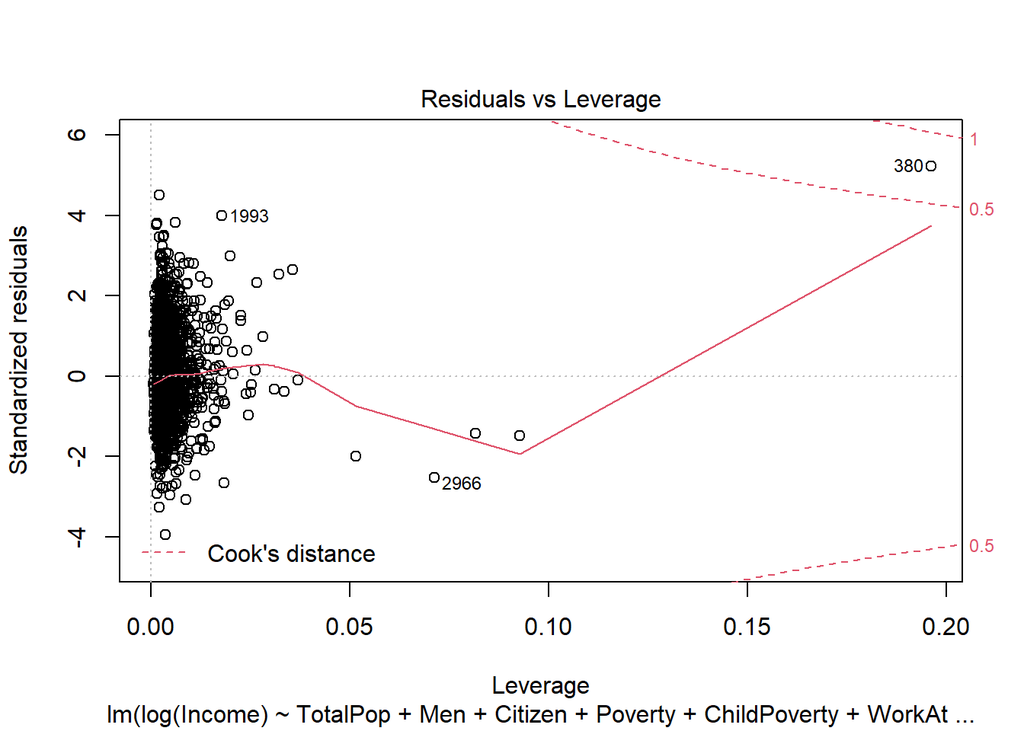

```
##
## Call:
## lm(formula = log(Income) ~ TotalPop + Men + Citizen + Poverty +
##     ChildPoverty + WorkAtHome + Employed + Unemployment, data = subset1)
##
## Residuals:
##     Min      1Q  Median      3Q     Max
## -0.3664 -0.0586 -0.0099  0.0492  0.4346
##
## Coefficients:
##               Estimate Std. Error t value Pr(>|t|)
## (Intercept)   1.11e+01   1.19e-02  934.03  < 2e-16 ***
## TotalPop     -4.90e-06   2.37e-06   -2.07    0.038 *
## Men           2.15e-05   3.82e-06    5.62  2.2e-08 ***
## Citizen      -1.46e-05   1.28e-06  -11.33  < 2e-16 ***
## Poverty      -2.61e-02   9.49e-04  -27.51  < 2e-16 ***
## ChildPoverty  7.56e-04   5.77e-04    1.31    0.191
## WorkAtHome    3.64e-03   1.17e-03    3.10    0.002 **
## Employed      1.60e-05   1.47e-06   10.92  < 2e-16 ***
## Unemployment -4.19e-03   9.32e-04   -4.50  7.3e-06 ***
## ---
## Signif. codes:  0 '***' 0.001 '**' 0.01 '*' 0.05 '.' 0.1 ' ' 1
##
## Residual standard error: 0.0929 on 2064 degrees of freedom
## Multiple R-squared:  0.775,  Adjusted R-squared:  0.774
## F-statistic:  887 on 8 and 2064 DF,  p-value: <2e-16
```

The statistical summary for this model is shown above. Now let’s compare the CV error.

```
## [1] 1.99e+09
```

The MSE calculated from cross-validation is approximately the same but slightly smaller than the previous linear model. Thus, the linear model using our selected predictors might predict Income more precisely.

*Subset Selection*

Noticing the fact that we have a relevantly large data set with a large number of rows, as well as 17 predictors, we choose to use backward-stepwise subset selection to do model selection.

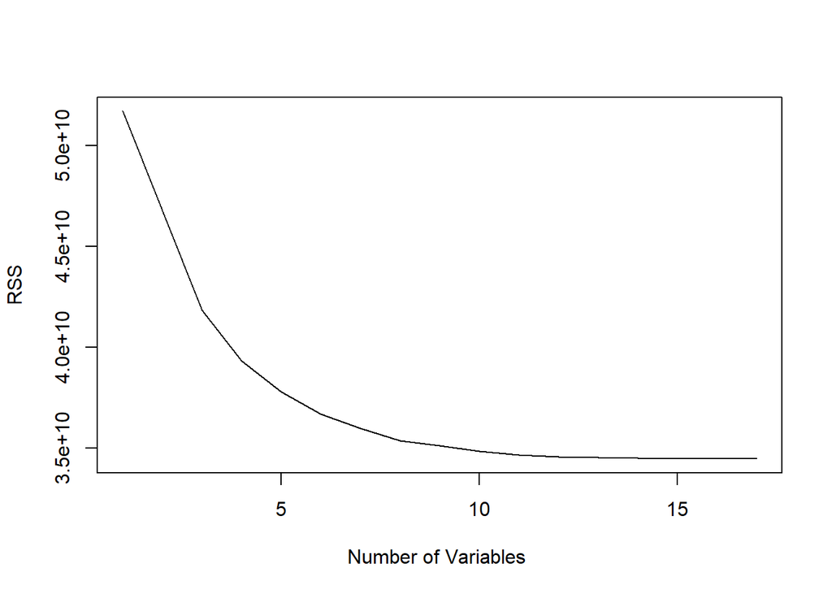

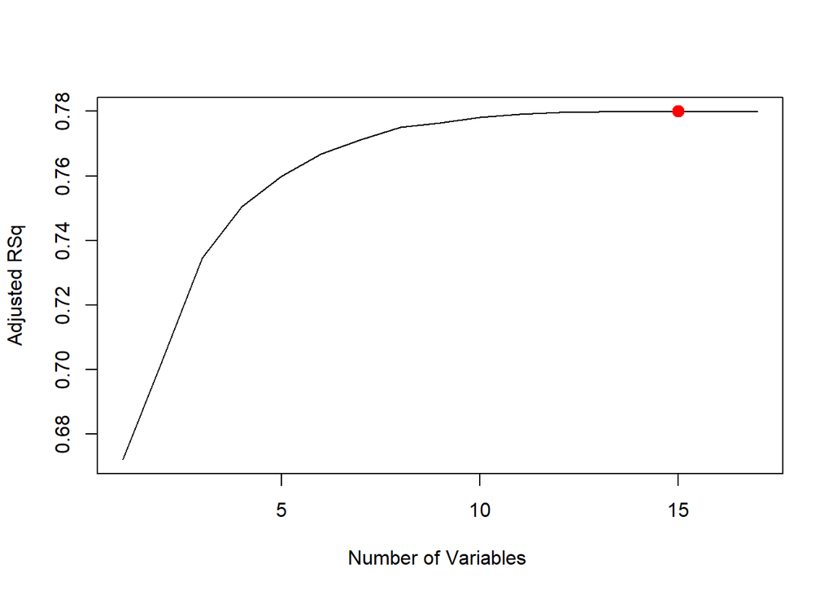

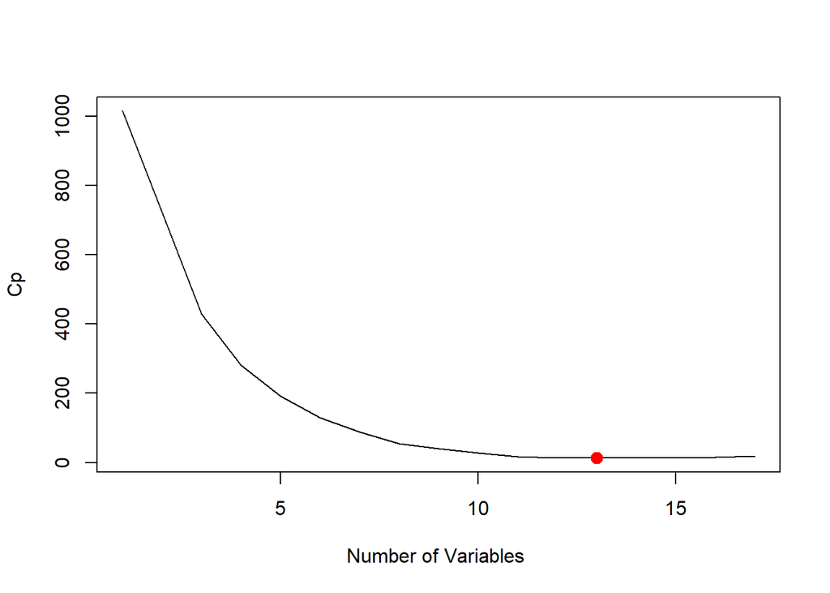

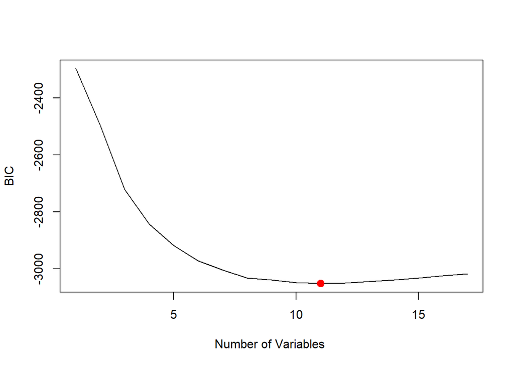

```
## [1] 15
## [1] 13
## [1] 11
```

We will first calculate the CV MSE with a subset of our own choice. Since we want to maximize the Adjusted R-squared value as well as minimize Cp and BIC values. We choose an id of 12. And the MSE for modeling with id=12 is 17159885.

```
## [1] 17159885
```

Now we loop through different ids to see the MSE for the best subset selected by CV method.

```
## [1] 15
## [1] 17087034
```

The model with 15 variables turns out to be the best with a MSE of 1.708*10^7

*Principal Component Regression*

Now let’s use the pcr function to fit a model with 10-fold cross validation to see how this model performs.

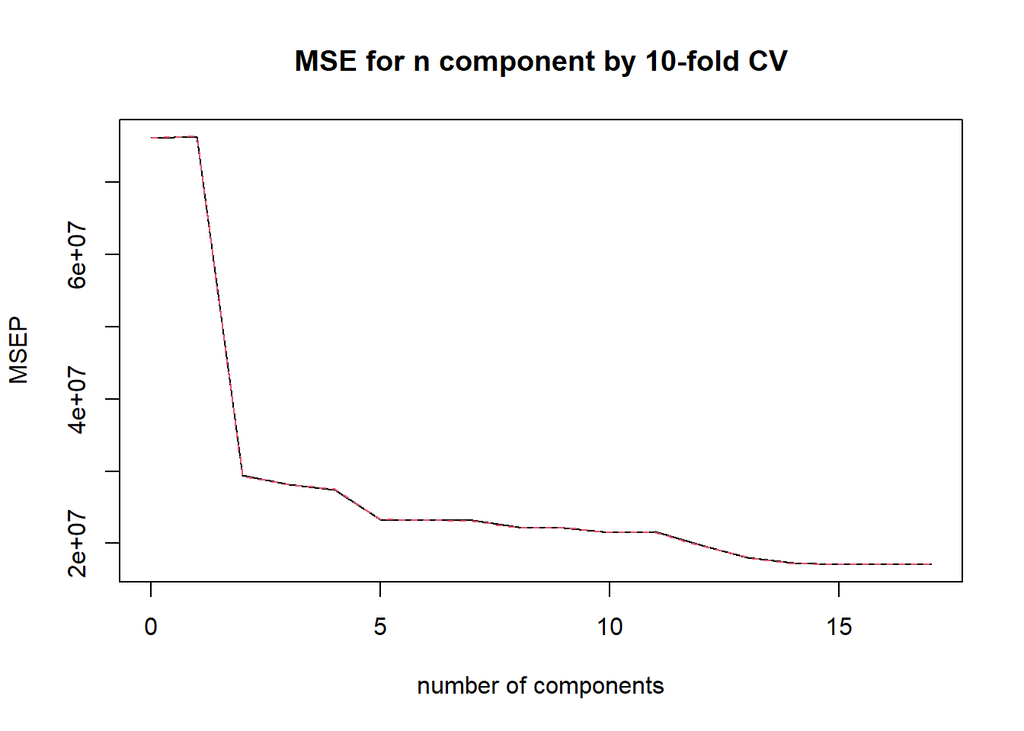

Reading from the plot, we can see that the lowest MSE appears when we use 15 component, which is approximately 2e+07.

*Shrinkage Methods*

*Ridge regression*:

Last but not least, we also use the shrinkage method to fit both ridge regression and lasso regression.

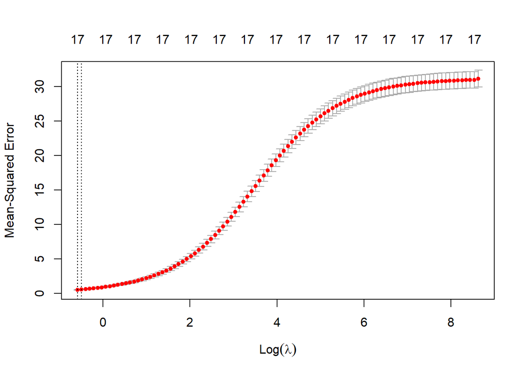

```
## [1] 0.558
## [1] 2.03e+09
```

We set alpha equals to 0 and we can see that the MSE for the prediction increases slightly from 0 to 2, then the increment accelerates from 2 to 5, and finally slows down from 5 to 8. From the CV, we get our best lambda value of 0.558. The MSE for ridge regression model with $\lambda$=0.558 is 2.03e+09

*Lasso Regression*

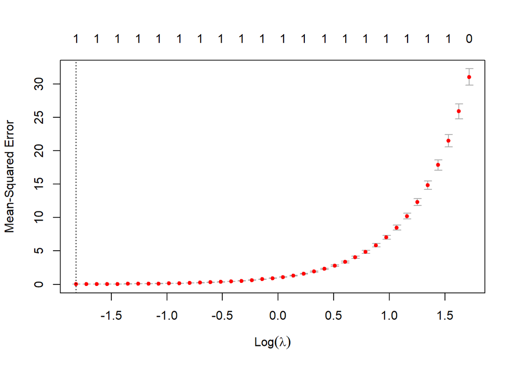

```
## [1] 0.163
## [1] 2.03e+09
```

The plot shows a slight increase of MSE as log lambda increases until it reaches 0.5, then the increment accelerates for larger log values. From the CV, we get our best lambda value of 0.163, and the MSE for lasso regression model with $\lambda$=0.163 is 2.03e+09.

*Conclusion*